# Cómo predicen los HMM los comportamientos de los monos

Análisis basado en Modelos de Markov Ocultos (HMM) y Matrices de Confusión

2024-21-10

## Librerias

```r
library(sf)
library(tidyverse)
library(caret)
library(reshape2)
library(gt)
library(momentuHMM)
library(gridExtra)
library(showtext)
```

## Modelo 10 minutos

```r
all_10 <- readRDS("BD_TODOS_GRUPOS_10_min.rds")

all_10 <- all_10 %>%
  mutate(ACTIVIDAD_GRUPAL = case_when(
    ACTIVIDAD_GRUPAL %in% c("Sleep_area", "Intergrup_Meeting") ~ "Rest_Soci",
    TRUE ~ ACTIVIDAD_GRUPAL )) %>%
  rename(id = GRUPO,
    act_grupal = ACTIVIDAD_GRUPAL,
         t=FECHA_HORA,
         lon = Longitud_AL,
         lat = Latitud_AL,
         ad_lib=ADICIONAL_LIBRETA,
         obs=OBSERVADOR)

all_10_sf <-
  all_10 %>%
  st_as_sf(
    coords = c(
      'lon',
      'lat'),
    crs = 4326) %>%
  st_transform(crs=32721)

all_sf_coords <-
  all_10_sf %>%
  st_coordinates()

X <- all_sf_coords[,"X"]
Y <- all_sf_coords[,"Y"]

all_10_utm <- cbind(
  all_10,
  X,
  Y)
```

Ahora agarro ese con las UTM y lo preparo para correr los HMM de 3 estados

```r
all_hmm_prep <-
  prepData(
    all_10_utm, type = "UTM",
    coordNames = c("X","Y"))

stepMean0 <- c(m1 = 10, m2 = 70, m3 = 200)
stepSD0 <- c(sd1 = 10, sd2 = 70, sd3 = 200)
stepZeroMass_3 <- c(zm1 = 0.1, zm2 = 0.1, zm3 = 0.1)
angleCon0 <- c(rho1  = 0.2, rho2 = 0.4, rho3 = 0.9)

stateNames <- c("resident-slow", "resident-faster", "transit")

dist <- list(step = "gamma", angle = "wrpcauchy")
Par0 <- list(step=c(stepMean0, stepSD0, stepZeroMass_3), angle = c(angleCon0))


all_hmm3 <- fitHMM(data = all_hmm_prep, nbStates = 3,
                   dist = dist, Par0 = Par0,
                   stateNames = stateNames,
                   formula = ~1)


hmm_3states <- viterbi(all_hmm3)
prop.table(table(hmm_3states))
```

```
## hmm_3states
##          1          2          3
## 0.23054531 0.70929556 0.06015913
```

```r
all_10_utm <- all_10_utm %>%
  mutate(state3 = hmm_3states) %>%
  mutate(state3 = as.factor(state3))

all_10_utm <- all_10_utm %>%
  mutate(act_grupal2 = case_when(
    act_grupal %in% c("Rest_Soci", "Fora_Feed") ~ "Rest_Fora_Feed",
    act_grupal == "Trav" ~ "Trav",
    act_grupal == "SIN_AG" ~ "SIN_AG",
    TRUE ~ NA_character_))
```

Ya teniendo la columna de los estados predichos (state3) y la de los estados observados (act_grupal) puedo empezar a acomadar para hacer la matriz de confusión

```r
# preparo para la matriz de confusion

# hago para 3 estados

all_10_utm <- all_10_utm %>%
  filter(act_grupal != "SIN_AG") %>%
  mutate(
    predicho3 = case_when(
      state3 == 1 ~ "Rest_Soci",
      state3 == 2 ~ "Fora_Feed",
      state3 == 3 ~ "Trav",
      TRUE ~ NA_character_ ))


all_10_utm$act_grupal <- droplevels(factor(all_10_utm$act_grupal))
all_10_utm$predicho3 <- droplevels(factor(all_10_utm$predicho3))

# paso importante, sino no corre

levels(all_10_utm$predicho3) <- levels(all_10_utm$act_grupal)
```

Macuco tiene muy pocos puntos así que mejor lo saco, se uso individualmente para ajustar el modelo pero acá no lo vamos a interpretar

```r
all_10_utm <- all_10_utm %>% dplyr::filter(id != 'Macuco2009')

conf_matrix_10 <-
  confusionMatrix(all_10_utm$predicho3,
                  all_10_utm$act_grupal)

conf_matrix_df <- as.data.frame(as.table(conf_matrix_10$table))

conf_matrix_df
```

| Prediction | Reference | Freq |
| --- | --- | --- |
| Fora_Feed | Fora_Feed | 1018 |
| Rest_Soci | Fora_Feed | 658 |
| Trav | Fora_Feed | 55 |
| Fora_Feed | Rest_Soci | 64 |
| Rest_Soci | Rest_Soci | 212 |
| Trav | Rest_Soci | 15 |
| Fora_Feed | Trav | 174 |
| Rest_Soci | Trav | 31 |
| Trav | Trav | 12 |

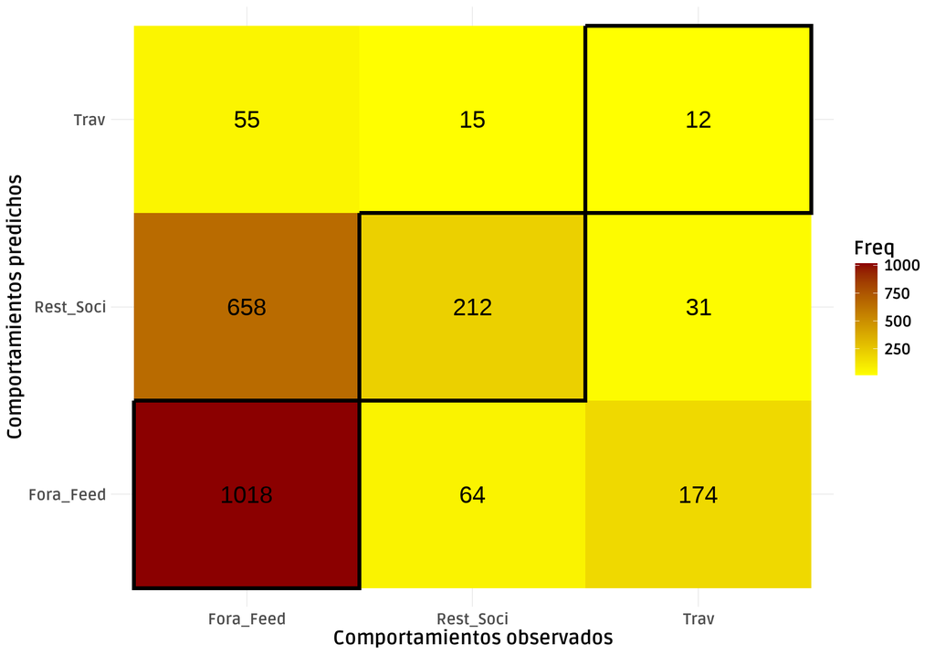

```r
font_add_google("Ruda", "ruda")
showtext_auto()

plot10 <- ggplot(data = conf_matrix_df, aes(x = Reference, y = Prediction, fill = Freq)) +
  geom_tile() +
  geom_text(aes(label = Freq), color = "black", size = 13) +
  scale_fill_gradient(low = "yellow", high = "darkred") +
  labs(x = "Comportamientos observados", y = "Comportamientos predichos") +
  theme_minimal() +
  theme(text = element_text(
    family = "ruda",
    face = 'bold',
    size = 30))+
  geom_tile(data = subset(conf_matrix_df, Reference == Prediction),
            color = "black", size = 1.5, fill = NA)

plot10
```

Veo cómo fueron las predicciones a nivel de movimietnos y del espacio

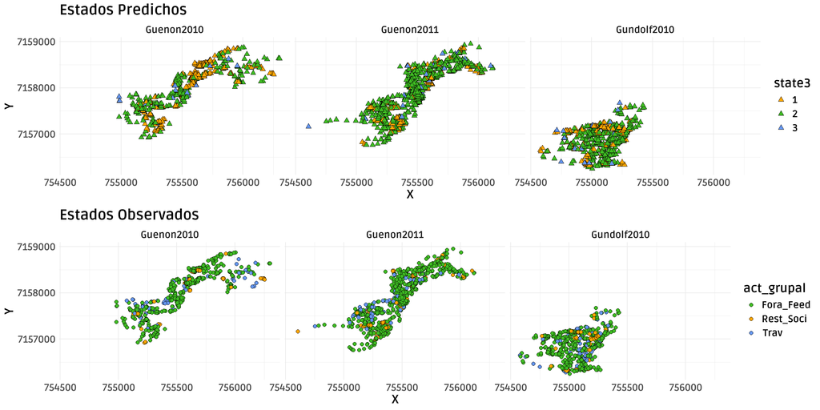

```r
plot_all_10min <- all_10_utm  %>%
  ggplot(aes(x = X,
             y = Y,
             fill = state3,
             col = state3)) +
  geom_point(shape = 24,
             size = 2,
             alpha = 1.1,
             col = "black") +
  scale_fill_manual(
    values = c("orange",
               "#3ebb22",
               "cornflowerblue")) +
  scale_color_manual(
    values = c("orange",
               "#3ebb22",
               "cornflowerblue")) +
  facet_wrap(~id)+
  theme_minimal() +
  labs(X = "lon",
       Y = "lat") +
  theme(text = element_text(
    family = "ruda",
    face = 'bold',
    size = 30))


plot_all_10min_obs <- all_10_utm  %>%
  ggplot(aes(x = X,
             y = Y,
             fill = act_grupal,
             col = act_grupal)) +
  geom_point(shape = 21,
             size = 2,
             alpha = 1.1,
             col = "black") +
  scale_fill_manual(
    values = c("#3ebb22",
               "orange",
               "cornflowerblue")) +
  scale_color_manual(
    values = c("#3ebb22",
               "orange",
               "cornflowerblue")) +
  facet_wrap(~id)+
  theme_minimal() +
  labs(X = "lon",
       Y = "lat") +
  theme(text = element_text(
    family = "ruda",
    face = 'bold',
    size = 30))

plot_all_10min <- plot_all_10min + ggtitle("Estados Predichos")
plot_all_10min_obs <- plot_all_10min_obs + ggtitle("Estados Observados")

grid.arrange(plot_all_10min, plot_all_10min_obs, nrow = 2)
```

## Modelo 30 minutos

Ahora hago lo mismo pero para el remuestreo de anto de los **30 minutos**

```r
all_30 <- readRDS("BD_TODOS_GRUPOS_30_min.rds")

all_30 <- all_30 %>%
  mutate(ACTIVIDAD_GRUPAL = case_when(
    ACTIVIDAD_GRUPAL %in% c("Sleep_area", "Intergrup_Meeting") ~ "Rest_Soci",
    TRUE ~ ACTIVIDAD_GRUPAL )) %>%
  rename(act_grupal = ACTIVIDAD_GRUPAL,
         t=FECHA_HORA,
         lon = Longitud_AL,
         lat = Latitud_AL,
         ad_lib=ADICIONAL_LIBRETA,
         obs=OBSERVADOR)

all_30_sf <-
  all_30 %>%
  st_as_sf(
    coords = c(
      'lon',
      'lat'),
    crs = 4326) %>%
  st_transform(crs=32721)

all_30_sf_coords <-
  all_30_sf %>%
  st_coordinates()

X <- all_30_sf_coords[,"X"]
Y <- all_30_sf_coords[,"Y"]

all_30_utm <- cbind(
  all_30,
  X,
  Y)
```

Hago los **Modelos Ócultos de Markov** para 30 minutos y 3 estados, dada la mayor cantidad de tiempo entre las locs agrando un poco los *Step Lengths* de las priors

```r
all_hmm_prep_30 <-
  prepData(
    all_30_utm, type = "UTM",
    coordNames = c("X","Y"))

stepMean0 <- c(m1 = 30, m2 = 100, m3 = 200)
stepSD0 <- c(sd1 = 20, sd2 = 100, sd3 = 200)
stepZeroMass_3 <- c(zm1 = 0.1, zm2 = 0.1, zm3 = 0.1)
angleCon0 <- c(rho1  = 0.1, rho2 = 0.5, rho3 = 0.7)

stateNames <- c("resident-slow", "resident-faster", "transit")

dist <- list(step = "gamma", angle = "wrpcauchy")
Par0 <- list(step=c(stepMean0, stepSD0, stepZeroMass_3), angle = c(angleCon0))


all_hmm3_30 <- fitHMM(data = all_hmm_prep_30, nbStates = 3,
                   dist = dist, Par0 = Par0,
                   stateNames = stateNames,
                   formula = ~1)

# Algoritmo Viterbi para extraer la secuencia de estados más probable


hmm_3states_30 <- viterbi(all_hmm3_30)
prop.table(table(hmm_3states_30))
```

```
## hmm_3states_30
##          1          2          3
## 0.04380883 0.79036930 0.16582187
```

```r
all_30_utm <- all_30_utm %>%
  mutate(state3 = hmm_3states_30) %>%
  mutate(state3 = as.factor(state3))
```

Preparo la data.frame con la columna de states para hacer la Matriz de Confusión

```r
all_30_utm <- all_30_utm %>%
  filter(act_grupal != "SIN_AG") %>%
  mutate(
    predicho3 = case_when(
      state3 == 1 ~ "Rest_Soci",
      state3 == 2 ~ "Fora_Feed",
      state3 == 3 ~ "Trav",
      TRUE ~ NA_character_ ))

all_30_utm$act_grupal <- droplevels(factor(all_30_utm$act_grupal))
all_30_utm$predicho3 <- droplevels(factor(all_30_utm$predicho3))

levels(all_30_utm$predicho3) <- levels(all_30_utm$act_grupal)

conf_matrix_30 <-
  confusionMatrix(all_30_utm$predicho3,
                  all_30_utm$act_grupal)

conf_matrix_df_30 <- as.data.frame(as.table(conf_matrix_30$table))
conf_matrix_df_30
```

| Prediction | Reference | Freq |
| --- | --- | --- |
| Fora_Feed | Fora_Feed | 638 |
| Rest_Soci | Fora_Feed | 23 |
| Trav | Fora_Feed | 153 |
| Fora_Feed | Rest_Soci | 61 |
| Rest_Soci | Rest_Soci | 4 |
| Trav | Rest_Soci | 69 |
| Fora_Feed | Trav | 98 |
| Rest_Soci | Trav | 6 |
| Trav | Trav | 10 |

Ploteo la matriz de confusión para los **30 minutos**

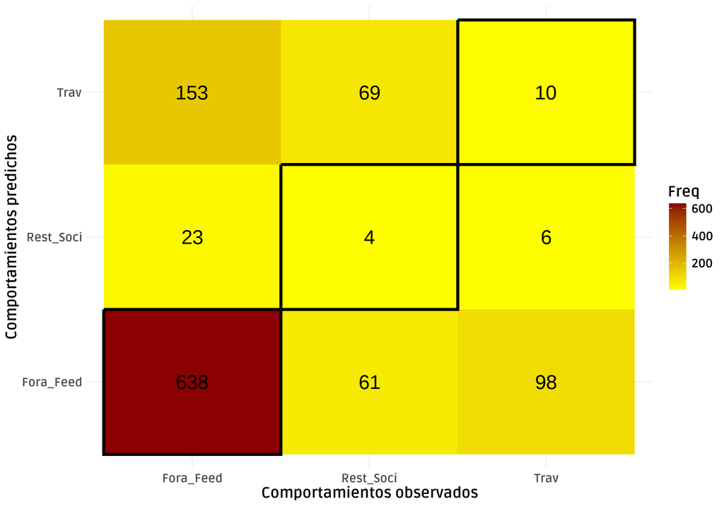

```r
plot30<- ggplot(data = conf_matrix_df_30, aes(x = Reference, y = Prediction, fill = Freq)) +
  geom_tile() +
  geom_text(aes(label = Freq), color = "black", size = 14) +
  scale_fill_gradient(low = "yellow", high = "darkred") +
  labs(x = "Comportamientos observados", y = "Comportamientos predichos") +
  theme_minimal() +
  theme(text = element_text(
    family = "ruda",
    face = 'bold',
    size = 30))+
  geom_tile(data = subset(conf_matrix_df, Reference == Prediction),
            color = "black", size = 1.5, fill = NA)
plot30
```

## Modelo 60 Minutos

```r
all_60 <- readRDS("BD_TODOS_GRUPOS_60_min.rds")

all_60 <- all_60 %>%
  mutate(ACTIVIDAD_GRUPAL = case_when(
    ACTIVIDAD_GRUPAL %in% c("Sleep_area", "Intergrup_Meeting") ~ "Rest_Soci",
    TRUE ~ ACTIVIDAD_GRUPAL )) %>%
  rename(act_grupal = ACTIVIDAD_GRUPAL,
         t=FECHA_HORA,
         lon = Longitud_AL,
         lat = Latitud_AL,
         ad_lib=ADICIONAL_LIBRETA,
         obs=OBSERVADOR)

all_60_sf <-
  all_60 %>%
  st_as_sf(
    coords = c(
      'lon',
      'lat'),
    crs = 4326) %>%
  st_transform(crs=32721)

all_60_sf_coords <-
  all_60_sf %>%
  st_coordinates()

X <- all_60_sf_coords[,"X"]
Y <- all_60_sf_coords[,"Y"]

all_60_utm <- cbind(
  all_60,
  X,
  Y)
```

Genero los **Modelos Ócultos de Markov** para los 60 minutos. Agrandé un poco más los *Step Lengths* concordantemente con el aumento de la resolución temporal de recolección

```r
all_hmm_prep_60 <-
  prepData(
    all_60_utm, type = "UTM",
    coordNames = c("X","Y"))

stepMean0 <- c(m1 = 50, m2 = 150, m3 = 300)
stepSD0 <- c(sd1 = 20, sd2 = 150, sd3 = 300)
stepZeroMass_3 <- c(zm1 = 0.1, zm2 = 0.1, zm3 = 0.1)
angleCon0 <- c(rho1  = 0.1, rho2 = 0.4, rho3 = 0.7)

stateNames <- c("resident-slow", "resident-faster", "transit")

dist <- list(step = "gamma", angle = "wrpcauchy")
Par0 <- list(step=c(stepMean0, stepSD0, stepZeroMass_3), angle = c(angleCon0))


all_hmm3_60 <- fitHMM(data = all_hmm_prep_60, nbStates = 3,
                      dist = dist, Par0 = Par0,
                      stateNames = stateNames,
                      formula = ~1)




hmm_3states_60 <- viterbi(all_hmm3_60)
prop.table(table(hmm_3states_60))
```

```
## hmm_3states_60
##         1         2         3
## 0.1079442 0.6361431 0.2559127
```

```r
all_60_utm <- all_60_utm %>%
  mutate(state3 = hmm_3states_60) %>%
  mutate(state3 = as.factor(state3))
```

Matriz de Confusión para el **Modelo de 60 min**

```r
all_60_utm <- all_60_utm %>%
  filter(act_grupal != "SIN_AG") %>%
  mutate(
    predicho3 = case_when(
      state3 == 1 ~ "Rest_Soci",
      state3 == 2 ~ "Fora_Feed",
      state3 == 3 ~ "Trav",
      TRUE ~ NA_character_ ))


all_60_utm$act_grupal <- droplevels(factor(all_60_utm$act_grupal))
all_60_utm$predicho3 <- droplevels(factor(all_60_utm$predicho3))

levels(all_60_utm$predicho3) <- levels(all_60_utm$act_grupal)

conf_matrix_60 <-
  confusionMatrix(all_60_utm$predicho3,
                  all_60_utm$act_grupal)

conf_matrix_df_60 <- as.data.frame(as.table(conf_matrix_60$table))
conf_matrix_df_60
```

| Prediction | Reference | Freq |
| --- | --- | --- |
| Fora_Feed | Fora_Feed | 306 |
| Rest_Soci | Fora_Feed | 48 |
| Trav | Fora_Feed | 95 |
| Fora_Feed | Rest_Soci | 35 |
| Rest_Soci | Rest_Soci | 10 |
| Trav | Rest_Soci | 30 |
| Fora_Feed | Trav | 54 |
| Rest_Soci | Trav | 6 |
| Trav | Trav | 6 |

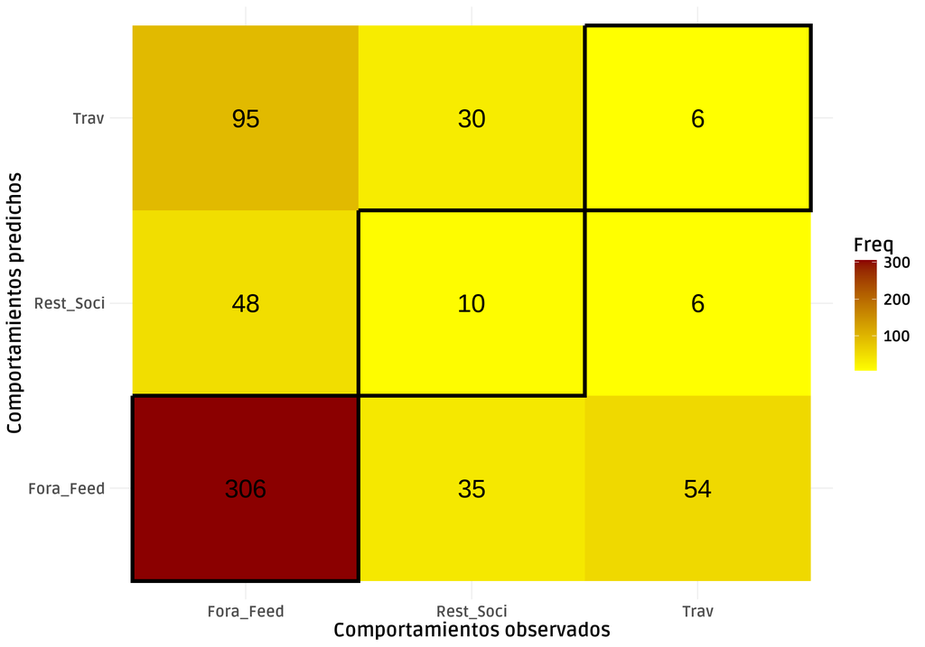

```r
plot60<- ggplot(data = conf_matrix_df_60, aes(x = Reference, y = Prediction, fill = Freq)) +
  geom_tile() +
  geom_text(aes(label = Freq), color = "black", size = 14) +
  scale_fill_gradient(low = "yellow", high = "darkred") +
  labs(x = "Comportamientos observados", y = "Comportamientos predichos") +
  theme_minimal() +
  theme(text = element_text(
    family = "ruda",
    face = 'bold',
    size = 30))+
  geom_tile(data = subset(conf_matrix_df, Reference == Prediction),
            color = "black", size = 1.5, fill = NA)
plot60
```

## Resumen de las Matrices de Confusión

```r
extract_confusion_matrix_summary <- function(conf_matrix) {

  overall_stats <- conf_matrix$overall
  by_class_stats <- conf_matrix$byClass


  sensitivity <- by_class_stats[, "Sensitivity"]
  specificity <- by_class_stats[, "Specificity"]
  balanced_accuracy <- by_class_stats[, "Balanced Accuracy"]

  summary_df <- data.frame(
    Accuracy = overall_stats["Accuracy"],
    NIR = overall_stats["AccuracyNull"],
    Kappa = overall_stats["Kappa"],
    Sensitivity_Fora_Feed = sensitivity[1],
    Sensitivity_Rest_Soci = sensitivity[2],
    Sensitivity_Trav = sensitivity[3],
    Specificity_Fora_Feed = specificity[1],
    Specificity_Rest_Soci = specificity[2],
    Specificity_Trav = specificity[3],
    Balanced_Accuracy_Fora_Feed = balanced_accuracy[1],
    Balanced_Accuracy_Rest_Soci = balanced_accuracy[2],
    Balanced_Accuracy_Trav = balanced_accuracy[3]
  )

  return(summary_df)
}

summary_conf_matrix_60 <- extract_confusion_matrix_summary(conf_matrix_60)
summary_conf_matrix_30 <- extract_confusion_matrix_summary(conf_matrix_30)
summary_conf_matrix_10 <- extract_confusion_matrix_summary(conf_matrix_10)

summary_all <- bind_rows(
  `Model 60` = summary_conf_matrix_60,
  `Model 30` = summary_conf_matrix_30,
  `Model 10` = summary_conf_matrix_10,
  .id = "Model")
rownames(summary_all) <- NULL

summary_transposed <- summary_all %>%
  pivot_longer(cols = -Model, names_to = "Metric", values_to = "Value") %>%
  pivot_wider(names_from = Model, values_from = Value)

summary_transposed <- summary_transposed %>%
  mutate(Metric = case_when(
    Metric == "Sensitivity_Fora_Feed" ~ "Sensitivity (Foraging/Feeding)",
    Metric == "Sensitivity_Rest_Soci" ~ "Sensitivity (Resting/Social)",
    Metric == "Sensitivity_Trav" ~ "Sensitivity (Travelling)",
    Metric == "Specificity_Fora_Feed" ~ "Specificity (Foraging/Feeding)",
    Metric == "Specificity_Rest_Soci" ~ "Specificity (Resting/Social)",
    Metric == "Specificity_Trav" ~ "Specificity (Travelling)",
    Metric == "Balanced_Accuracy_Fora_Feed" ~ "Balanced Accuracy (Foraging/Feeding)",
    Metric == "Balanced_Accuracy_Rest_Soci" ~ "Balanced Accuracy (Resting/Social)",
    Metric == "Balanced_Accuracy_Trav" ~ "Balanced Accuracy (Travelling)",
    TRUE ~ Metric))


gt_table <-
  summary_transposed %>%
  gt() %>%
  tab_header(
    title = "Predictive Capacity of Each Model",
    subtitle = "Hidden Markov Models for predict Black Capuchins behaviors"
  ) %>%
  fmt_number(
    columns = everything(),
    decimals = 3
  ) %>%
  cols_label(
    Metric = "Metric",
    `Model 60` = "Model-60 min",
    `Model 30` = "Model-30 min",
    `Model 10` = "Model-10 min"
  ) %>%
  tab_options(
    table.font.size = "small",
    heading.title.font.size = "medium",
    heading.subtitle.font.size = "small"
  ) %>%
  opt_align_table_header(align = "left")
```

Grilla para las 3 matrices de confusión

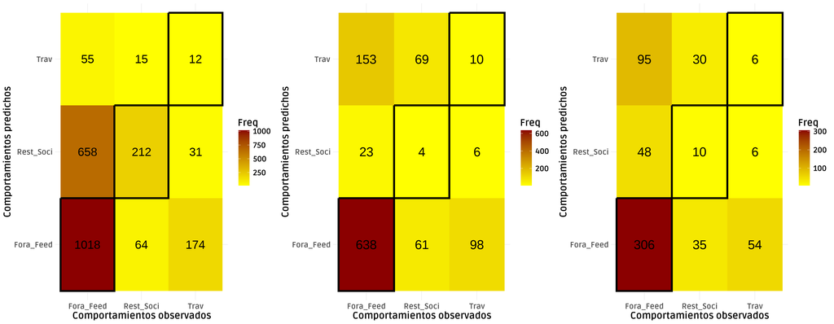

```r
grid.arrange(plot10, plot30, plot60, ncol = 3)
```

Tabla de resumen con varias métricas

```r
gt_table
```

Predictive Capacity of Each Model

Hidden Markov Models for predict Black Capuchins behaviors

| Metric | Model-60 min | Model-30 min | Model-10 min |
| --- | --- | --- | --- |
| Accuracy | 0.546 | 0.614 | 0.555 |
| NIR | 0.761 | 0.766 | 0.773 |
| Kappa | −0.005 | 0.029 | 0.128 |
| Sensitivity (Foraging/Feeding) | 0.682 | 0.784 | 0.588 |
| Sensitivity (Resting/Social) | 0.133 | 0.030 | 0.729 |
| Sensitivity (Travelling) | 0.091 | 0.088 | 0.055 |
| Specificity (Foraging/Feeding) | 0.369 | 0.359 | 0.531 |
| Specificity (Resting/Social) | 0.895 | 0.969 | 0.646 |
| Specificity (Travelling) | 0.761 | 0.766 | 0.965 |
| Balanced Accuracy (Foraging/Feeding) | 0.525 | 0.571 | 0.560 |
| Balanced Accuracy (Resting/Social) | 0.514 | 0.499 | 0.687 |
| Balanced Accuracy (Travelling) | 0.426 | 0.427 | 0.510 |

## Métricas de las Matrices

- **Macro Precision**, promedio de la precisión para cada clase:

$$\text{Macro Precision} = \frac{1}{n} \sum_{i=1}^{n} \frac{TP_i}{TP_i +
FP_i}$$

Donde: - $TP_i$ son los verdaderos positivos para la clase $i$, - $FP_i$ son los falsos positivos para la clase $i$, - $n$ es el número total de clases.

- **Macro Recall** es el promedio de la sensibilidad (recall) para cada clase:

$$\text{Macro Recall} = \frac{1}{n} \sum_{i=1}^{n} \frac{TP_i}{TP_i +
FN_i}$$

Donde: - $TP_i$ son los verdaderos positivos para la clase $i$, - $FN_i$ son los falsos negativos para la clase $i$, - $n$ es el número total de clases.

- **Macro F1-Score** es el promedio del F1-Score para cada clase:

$$\text{Macro F1-Score} = \frac{1}{n} \sum_{i=1}^{n} \frac{2 \cdot
\text{Precision}_i \cdot \text{Recall}_i}{\text{Precision}_i +
\text{Recall}_i}$$

Donde: - La **Precision** de cada clase $i$ es $\frac{TP_i}{TP_i + FP_i}$, - La **Recall** de cada clase $i$ es $\frac{TP_i}{TP_i + FN_i}$.

La precisión global mide qué porcentaje de las predicciones del modelo fueron correctas, pero puede ser tramposa cuando el conjunto de datos está desbalanceado, es decir, cuando algunas clases (en este caso los comportamientos) son mucho más frecuentes que otras. En este contexto, un modelo podría tener una alta precisión simplemente prediciendo siempre la clase mayoritaria, ignorando las clases menos frecuentes (como Travelling o Resting/Social), que son igualmente importantes en este análisis.

**Macro Precision**

Esta métrica me permitirá evaluar cuán preciso es el modelo al predecir cada clase en promedio. Específicamente, mide qué tan bien el modelo predice correctamente cada comportamiento sin importar la cantidad de ejemplos por clase. Esto es útil en mi caso porque me permitirá identificar si el modelo está haciendo un buen trabajo prediciendo comportamientos raros como Travelling, que tienden a ser ignorados por modelos que se centran en la clase más frecuente (Foraging/Feeding).

**Macro Recall**

La sensibilidad es fundamental en este análisis porque indica cuán bien el modelo está capturando los comportamientos observados, en promedio, para cada clase. Al ser una métrica que trata todas las clases por igual, el Macro Recall me permitirá evaluar si el modelo está detectando correctamente los comportamientos menos frecuentes, algo que sería difícil de ver solo con la precisión global. Si el modelo falla en detectar comportamientos poco frecuentes, la sensibilidad para esas clases será baja, y esta métrica capturará esa deficiencia.

**Macro F1-Score**

El F1-Score es la media armónica entre la precisión y el recall. En el contexto de este análisis, el Macro F1-Score esta piola para evaluar el rendimiento general del modelo, un alto F1-Score indicará que el modelo no solo es preciso, sino que también tiene una buena capacidad para detectar correctamente cada comportamiento. Esto es particularmente importante para evitar que el modelo “se olvide” de las clases minoritarias mientras optimiza su rendimiento para las clases más frecuentes.